# Back to Confidence Intervals

Albert Y. Kim

Thu Dec 2, 2016

Load the familiar data again, removing individuals with no listed height

```r
library(mosaic)
library(dplyr)
library(ggplot2)
library(okcupiddata)
data(profiles)
set.seed(76)
profiles <- profiles %>%
  filter(!is.na(height))
```

We take many, many, many samples of size 5 and then take the sample mean, and then do the same for samples of size 50:

```r
n <- 5
samples_5 <- do(10000) *
  mean(resample(profiles$height, size=n, replace=TRUE))
samples_5 <- samples_5 %>%
  as_data_frame()

n <- 50
samples_50 <- do(10000) *
  mean(resample(profiles$height, size=n, replace=TRUE))
samples_50 <- samples_50 %>%
  as_data_frame()
```

## Learning Checks

Construct 95% confidence intervals for $\mu$, the true average height of all 60K OkCupid users

- Using both methods for constructing confidence intervals: quantiles and bell-curve aproach
- For both when `n=5` and `n=50`

Hint: Look at the histograms of the 10000 simulations.

## Notes

#### Quantiles

To get 95% confidence interval, we need

- the middle 95% (blue)
- so the tails represent 5% (red), i.e. 2.5% each
- thus we need the 2.5% and 97.5% percentiles
- thus we use `quantile()` with `prob=c(0.025, 0.975)`

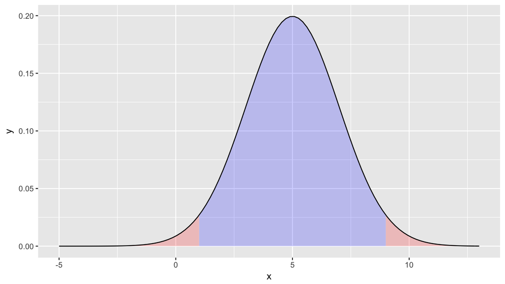

#### Normal Curve

We need the mean and the standard deviation of the **sampling distribution**, i.e. the distribution of the 10,000 $\overline{x}$. The latter is the **standard error**.

## n=5

**Quantiles**: Using the fact above

```r
quantile(samples_5$mean, prob=c(0.025, 0.975))
```

```
##  2.5% 97.5%
##  64.8  71.8
```

i.e. we have **(64.8, 71.8)**

**Normal-Curve Approach**:

```r
mean(samples_5$mean)
```

[output not shown]

```r
sd(samples_5$mean)
```

```
## [1] 1.797184
```

We plot the resulting confidence intervals i.e. **our net**

- Blue: Quantile contstructed
- Red: Normal curve constructed

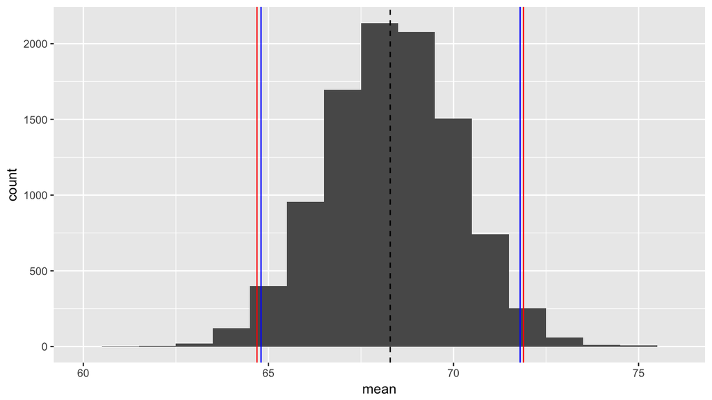

```r
ggplot(samples_5, aes(x=mean)) +
  geom_histogram(binwidth = 1) +
  xlim(c(60,76)) +
  geom_vline(xintercept = 68.29, linetype="dashed") +
  geom_vline(xintercept = c(64.8,  71.8), col="blue") +
  geom_vline(xintercept = c(64.69, 71.89), col="red")
```

## n=50

**Quantiles**: Using the fact above

```r
quantile(samples_50$mean, prob=c(0.025, 0.975))
```

```
##  2.5% 97.5%
## 67.18 69.38
```

i.e. we have **(67.18, 69.38)**

**Normal-Curve Approach**:

```r
mean(samples_50$mean)
```

```
## [1] 68.29883
```

```r
sd(samples_50$mean)
```

```
## [1] 0.5596155
```

We plot the resulting confidence intervals i.e. **our net**

- Blue: Quantile contstructed
- Red: Normal curve constructed

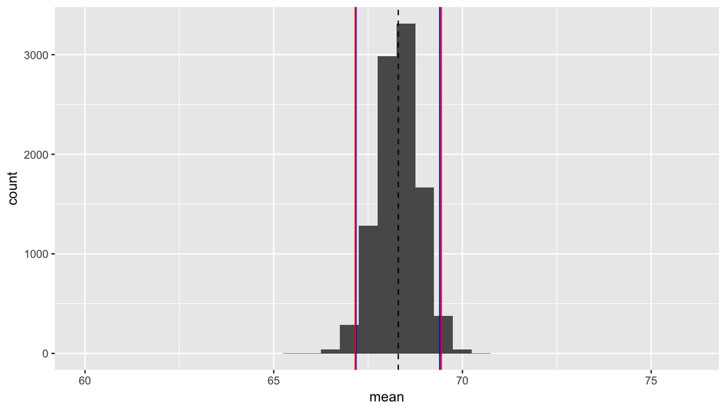

```r
ggplot(samples_50, aes(x=mean)) +
  geom_histogram(binwidth = 0.5) +
  xlim(c(60,76)) +
  geom_vline(xintercept = 68.30, linetype="dashed") +
  geom_vline(xintercept = c(67.18, 69.40), col="blue") +
  geom_vline(xintercept = c(67.16, 69.44), col="red")
```

## Conclusion

As expected, confidence interval is narrower for `n=50`. This is because the SE is smaller when `n=50`.